# Individual Project 3: r/Pizza Analysis

**DATS 6103 - Individual Project 3 - Lucia Illari (G24308643)**

I decided to scrap data from r/Pizza searching for the word `first` and for a list of the state abbreviations in the title of submissions from Jan 2017 to Dec 2020. I wanted to see what was the most popular type of pizza and the most popular pizza topings, as well as see if COVID had an impact on the number of people posting about making pizza for the first time. Then I wanted to see if maybe this increase was due to a natural increase in the subreddit's population, or if it did coincide with lockdown.

The first dataset, scrapping r/Pizza for submissions from Jan 2017 to Dec 2020 with `first` in the title, has 6061 instances. The second dataset, scrapping for the same time period but search for any state abbreviation in the title, has 8893 instances. Both datasets have the columns

- Full Submission ID
- Submission Title
- Permalink
- Author
- Flair
- Total Comments
- Upvotes
- Year
- Month
- Day
- Time
- Upvote Ratio
- Total Awards
- Gilded

```python
#import necessary packages
import csv
import re
import os
from os import path
import pandas as pd
import praw
import requests
import json
import time
import folium
import datetime as dt
from PIL import Image
from IPython.display import IFrame
from wordcloud import WordCloud, STOPWORDS, ImageColorGenerator
import seaborn as sns
import matplotlib as mpl
import matplotlib.pyplot as plt
import matplotlib.dates as mdates
from statistics import mean, stdev, variance

import warnings
warnings.filterwarnings("ignore")

%matplotlib notebook

#get current directory
directory = os.getcwd()
```

# 1.) Scrapping the data

First thing's first, we need to scrap the data. One problem however with PRAW, the Python Reddit API Wrapper, is that we can only get about 1000 results, so we need to use Pushshift to get more results.

## 1.1) Pushshift

There are some parameters we need to keep in mind, and that is the epoch start and end time, the word we are searching for in post titles, and of course the subreddit we want th look through.

There is some data that I'm going to pull with Pushshift however some of it will not be accurate. For example, the scores will not be accurate. I can go back later with PRAW to get the right values and then to also get total awards, if the post was gildred, etc. The attributes that we will be pulling are:

- post id (we can use this later with PRAW to get teh extra data)
- post title
- permalink
- author
- flair
- total number of comments
- score (this will not always be accurate so we will have to use PRAW to get the correct values)
- date posted
- year posted
- month posted
- day posted
- time posted

**This scrapping ran faster in Google Collab, so check the rPizza_Pushshift_Data.ipython notebook for this portion.**

I will now import the csv file that was generated through this scrapping.

```python
pizza_data = pd.read_csv(directory+'\\rPizza_search-first_data.csv')
```

```python
pizza_data.head()
```

|  | Post_ID | Title | Permalink | Author | Flair | Total_Comments | Upvotes | Year | Month | Day | Time | Date | Year_Month |
| --- | --- | --- | --- | --- | --- | --- | --- | --- | --- | --- | --- | --- | --- |
| 0 | t3_5lemvq | My first round pizza. | /r/Pizza/comments/5lemvq/my_first_round_pizza/ | Red-Droid-Blue-Droid | NaN | 0 | 38 | 2017 | 1 | 1 | 10:23:45 | 2017-01-01 | 2017-01 |
| 1 | t3_5lfve9 | My first pizza. Tasted pretty good. | /r/Pizza/comments/5lfve9/my_first_pizza_tasted... | JuniperoBeachBabe | NaN | 2 | 15 | 2017 | 1 | 1 | 16:47:26 | 2017-01-01 | 2017-01 |
| 2 | t3_5lg107 | First pizza of 2017. My kid started to cry. | /r/Pizza/comments/5lg107/first_pizza_of_2017_m... | wutvuff | NaN | 129 | 2151 | 2017 | 1 | 1 | 17:20:45 | 2017-01-01 | 2017-01 |
| 3 | t3_5lgfx4 | Happy new year! Brunch pizza, and first of 2017! | /r/Pizza/comments/5lgfx4/happy_new_year_brunch... | liartellinglies | NaN | 0 | 2 | 2017 | 1 | 1 | 18:45:09 | 2017-01-01 | 2017-01 |
| 4 | t3_5lgoh1 | First pizza of the new year! Homemade deep-dis... | /r/Pizza/comments/5lgoh1/first_pizza_of_the_ne... | TheLizardKing731 | NaN | 0 | 6 | 2017 | 1 | 1 | 19:31:02 | 2017-01-01 | 2017-01 |

## 1.2) PRAW

We now turn to PRAW to update the score values, and to get some additional info, such as total awards and guilded.

You need a reddit account and to create an app before you can scrap with PRAW. **I have not included the text file with my Reddit login info because I have now put this section in a if/else clause.** I saved the data that I scrapped to a csv so that we don't run into a problem of this section not running when the entire notebook is ran.

```python
if path.exists("df_new.csv") == True:
    print('The csv file exists. Reading it now...')
    df_new = pd.read_csv(directory+'\\df_new.csv')
else:
    print('The csv file does not exist. Getting the data now...')

    #I want to hide my reddit info
    reddit_info = pd.read_csv(directory+'\\reddit_info.txt')

    #assign necessary info to variables
    clientId = reddit_info['client_id'][0]
    clientSecret = reddit_info['client_secret'][0]
    userAgent = reddit_info['user_agent'][0]
    userName = reddit_info['user_name'][0]
    pword = reddit_info['password'][0]

    #need to create an app with reddit before scrapping the content
    reddit = praw.Reddit(client_id=clientId,
                         client_secret=clientSecret,
                         user_agent=userAgent,
                         username=userName,
                         password=pword,
                        )

    #we need the list of submission ids
    ids = list(pizza_data['Post_ID'])

    #take the submission ids and use them to get the correct score info and some extra info
    df_new = pd.concat([pd.DataFrame({'Upvotes': i.ups,
                                      'Upvote_Ratio': i.upvote_ratio,
                                      'Total_Awards': i.total_awards_received,
                                      'Gilded':i.gilded,
                                     },
                                     index=[i])
                        for i in reddit.info(ids)],
                       ignore_index=True)

    #save to a csv to save for future use
    df_new.to_csv(directory+'\df_new.csv', index = False)
```

```
The csv file exists. Reading it now...
```

```python
#add the new columns to the old data
pizza_data['Upvotes'] = df_new['Upvotes']
pizza_data['Upvote_Ratio'] = df_new['Upvote_Ratio']
pizza_data['Total_Awards'] = df_new['Total_Awards']
pizza_data['Gilded'] = df_new['Gilded']

pizza_data.head()
```

|  | Post_ID | Title | Permalink | Author | Flair | Total_Comments | Upvotes | Year | Month | Day | Time | Date | Year_Month | Upvote_Ratio | Total_Awards | Gilded |
| --- | --- | --- | --- | --- | --- | --- | --- | --- | --- | --- | --- | --- | --- | --- | --- | --- |
| 0 | t3_5lemvq | My first round pizza. | /r/Pizza/comments/5lemvq/my_first_round_pizza/ | Red-Droid-Blue-Droid | NaN | 0 | 35 | 2017 | 1 | 1 | 10:23:45 | 2017-01-01 | 2017-01 | 0.97 | 0 | 0 |
| 1 | t3_5lfve9 | My first pizza. Tasted pretty good. | /r/Pizza/comments/5lfve9/my_first_pizza_tasted... | JuniperoBeachBabe | NaN | 2 | 12 | 2017 | 1 | 1 | 16:47:26 | 2017-01-01 | 2017-01 | 0.85 | 0 | 0 |
| 2 | t3_5lg107 | First pizza of 2017. My kid started to cry. | /r/Pizza/comments/5lg107/first_pizza_of_2017_m... | wutvuff | NaN | 129 | 2378 | 2017 | 1 | 1 | 17:20:45 | 2017-01-01 | 2017-01 | 0.98 | 0 | 0 |
| 3 | t3_5lgfx4 | Happy new year! Brunch pizza, and first of 2017! | /r/Pizza/comments/5lgfx4/happy_new_year_brunch... | liartellinglies | NaN | 0 | 2 | 2017 | 1 | 1 | 18:45:09 | 2017-01-01 | 2017-01 | 1.00 | 0 | 0 |
| 4 | t3_5lgoh1 | First pizza of the new year! Homemade deep-dis... | /r/Pizza/comments/5lgoh1/first_pizza_of_the_ne... | TheLizardKing731 | NaN | 0 | 6 | 2017 | 1 | 1 | 19:31:02 | 2017-01-01 | 2017-01 | 1.00 | 0 | 0 |

Great! Our score information is now fixed, and we have added a few extra columns.

# 2.) Summary statistics

Let's just very quickly look at some summary statistics (average upvotes per submission, comments, etc) and get a feel for the range of values in a whisker plot.

```python
pizza_data[["Total_Comments","Upvotes","Upvote_Ratio","Total_Awards","Gilded"]].describe()
```

|  | Total_Comments | Upvotes | Upvote_Ratio | Total_Awards | Gilded |
| --- | --- | --- | --- | --- | --- |
| count | 6061.000000 | 6061.000000 | 6061.000000 | 6061.000000 | 6061.000000 |
| mean | 5.960568 | 67.068636 | 0.885634 | 0.019139 | 0.001650 |
| std | 12.670328 | 208.220161 | 0.110294 | 0.199744 | 0.040589 |
| min | 0.000000 | 0.000000 | 0.200000 | 0.000000 | 0.000000 |
| 25% | 1.000000 | 6.000000 | 0.830000 | 0.000000 | 0.000000 |
| 50% | 2.000000 | 14.000000 | 0.910000 | 0.000000 | 0.000000 |
| 75% | 6.000000 | 36.000000 | 0.970000 | 0.000000 | 0.000000 |
| max | 276.000000 | 3969.000000 | 1.000000 | 5.000000 | 1.000000 |

We will see the same thing in the box plots, but the averages are all fairly low but for comments and upvotes there is the aboslute ability for values to blow up - those submissions are outliers though.

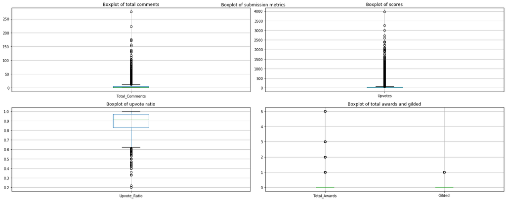

```python
fig, axs = plt.subplots(2,2, figsize=(20,8))

fig.suptitle('Boxplot of submission metrics')
pizza_data.boxplot(column=["Total_Comments"], ax=axs[0,0])
axs[0, 0].set_title('Boxplot of total comments')

pizza_data.boxplot(column=["Upvotes"], ax=axs[0,1])
axs[0, 1].set_title('Boxplot of scores')

pizza_data.boxplot(column=["Upvote_Ratio"], ax=axs[1,0])
axs[1, 0].set_title('Boxplot of upvote ratio')

pizza_data.boxplot(column=["Total_Awards","Gilded"], ax=axs[1,1])
axs[1, 1].set_title('Boxplot of total awards and gilded')

plt.tight_layout()
plt.show()
```

What we see is that both upvotes and comments have some pretty drastic outliers as compared to where the average post is, but that in general people aren't downvoting the posts a whole heck of a lot, so even if they don't get a lot of upvotes, the subreddit interactions are generally positive. This however is not a dataset where people are getting a lot of awards. It could be that first time pizzas just don't have all the panache that one wants before the give a submission an award.

# 3.) Most frequently used words in submission title

First thing's first, let's see what people are saying in these posts! We can do this via a word cloud. Maybe there is a type of pizza people make more often than others.

```python
text = " ".join(i.lower() for i in pizza_data['Title'])
```

```python
#create a stopword list
stopwords = set(STOPWORDS)
stopwords.update(["first", "attempt", "pizza", "making", "made", "try", "time", "pie", "homemade", "dough", "scratch", "home", "post", "tried", "think", "pizza"])
```

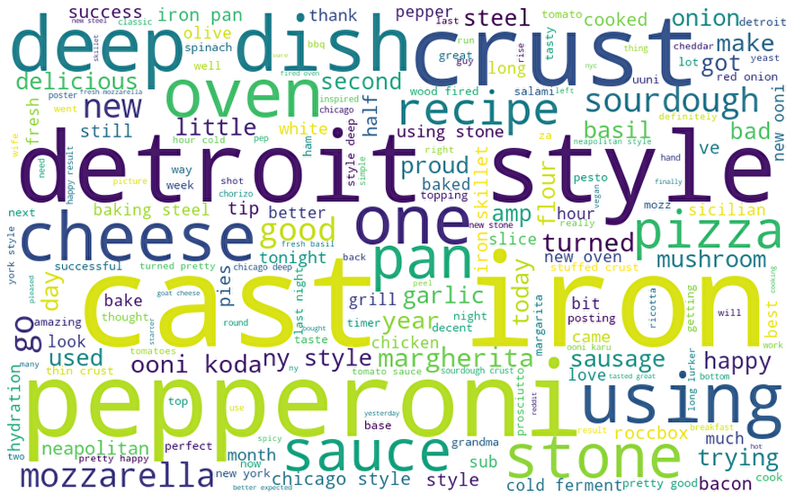

```python
wordcloud = WordCloud(background_color="white", stopwords=stopwords, width=800, height=500).generate(text)

plt.figure(figsize=(20,10))
plt.imshow(wordcloud, interpolation='sinc')
plt.axis("off")
plt.show()
```

The types of pizza I'm seeing is detroit, deep dish, chicago, ny (and york), margherita (and a few... margarita?), neapolitan, sicilian, grandma. Let's go ahead and get the counts of the most popular types of pizza and toppings.

But that is for all 6k+ submissions in this data set. What does this look like for the top 100 submissions to r/Pizza?

```python
#sort by upvotes and get top 500
top_100 = pizza_data.sort_values(by=['Upvotes'], ascending=False).head(100)

#get title information in one variable
top_100 = " ".join(i.lower() for i in top_100['Title'])
```

I'll use the same stopwords that I used for the previous wordcloud.

[figure not shown]

```python
wc_100 = WordCloud(background_color="white",
                      stopwords=stopwords,
                      width=800, height=500).generate(top_100)

plt.figure(figsize=(20,10))
plt.imshow(wc_100, interpolation='sinc')
plt.axis("off")
plt.show()
```

Now instead of `deep dish`, `oven` is very popular, and so is `new`, What I think might be going on is on the previous word cloud, I noticed that `ooni` and `ooni koda` had popped up, so what might be going on is people recently have been buying this new pizza overn and trying it out, and considering that `success` is also rather large, people might be satisfied with the results. I also see a small `valentine` so Valtine's Day pizza posts might be popular on this sub... Also interestingly we can see quarantine in this word cloud, so the top 100 posts in this dataset to seem to be discussing COVID,

# 4.) Most mentioned state

People are boudn to mention what state they're making pizza in, though it probably won't be a majority of the posts. Let's see what are the most frequently mentioned states on r/Pizza.

```python
states = ['al', 'ak', 'az', 'ar', 'ca', 'co', 'ct', 'de', 'fl', 'ga', 'hi', 'id',
          'il', 'in', 'ia', 'ks', 'ky', 'la', 'me', 'md', 'ma', 'mi', 'mn', 'ms',
          'mo', 'mt', 'ne', 'nv', 'nh', 'nj', 'nm', 'ny', 'nc', 'nd', 'oh', 'ok',
          'or', 'pa', 'ri', 'sc', 'sd', 'tn', 'tx', 'ut', 'va', 'vt', 'wa', 'wv', 'wi',
          'wy', 'as', 'dc', 'fm', 'gu', 'mh', 'mp', 'pw', 'pr', 'vi']
#want to convert all state initials to upper case
states = list(map(lambda x:x.upper(), states))
```

It's likely if I use the same string where all the titles are lower that `IN` and `ME` will be more than just state counts, so I want a text string that preserves upper and lowercases. I didn't get enough hits for states using the data where I searched for `first` in the title, so I scrapped r/Pizza for more data where I was searching the state initials. I will use that data here.

```python
pizza_states = pd.read_csv(directory+'\\rPizza_search-states.csv')

txt_states = " ".join(i for i in pizza_states['Title'])
```

```python
#it's possible that counts for NY are actually for the type of pizza, so I want to remove those
dif_combo = ['NY Style', 'NY style', 'NY-Style', 'NY-style', 'NYC-rustic', 'NY Pizza',
             'NY pizza', 'NY dough', 'NY American style', 'NY Slice', 'NY slice',
             'NY Grandma', 'NY grandma', 'NY cheeser', 'NY Cheeser', 'NY-politan',
             'NY Times', 'NY cheese', 'NY Cheese', 'NY. Style', 'NY. style', 'NY pie', 'NY Pie']
ny_c = 0
for word in dif_combo:
    ny_c = ny_c + sum(1 for _ in re.finditer(r'\b%s\b' % re.escape(word), txt_states))

print('There are '+str(ny_c)+' mentions of `NY Style` pizza in this data.')
```

```
There are 716 mentions of `NY Style` pizza in this data.
```

```python
state_hits = pd.concat([pd.DataFrame({'State': states[i],'Mentions': sum(1 for _ in re.finditer(r'\b%s\b' % re.escape(states[i]), txt_states))},index=[i])
           for i in range(len(states))],ignore_index=True)
#edit the NY value
state_hits = state_hits.replace(list(state_hits[state_hits["State"] == 'NY']['Mentions'])[0], list(state_hits[state_hits["State"] == 'NY']['Mentions'])[0]-ny_c)
```

```python
#want to convert to percentages
state_hits['Mentions%'] = state_hits['Mentions']/state_hits['Mentions'].sum()
```

Great now we have the hits for the states mentioned in posts. Let's go adjust the `NY` value.

```python
#load the shape of the united states
state_geo = os.path.join(directory, 'us-states.json')

#init the map
m = folium.Map(location=[37, -102], zoom_start=5)

#add color
m.choropleth(
    geo_data=state_geo,
    name='choropleth',
    data=state_hits,
    columns=['State', 'Mentions%'],
    key_on='feature.id',
    fill_color='YlGn',
    fill_opacity=0.7,
    line_opacity=0.2,
    legend_name='Mentions in r/Pizza Submission Titles (%)'
)
folium.LayerControl().add_to(m)
#save as html
m.save('heat_map_state_ment.html')
```

Now let's go ahead and display our heatmap!

```python
IFrame(src='heat_map_state_ment.html', width=700, height=600)
```

[interactive chart not shown]

# 5.) Most popular pizza types and toppings

First let's make a list of popular toppings and a list of different pizza types.

```python
topings = ['pepperoni','olive','cheese','cheddar','ricotta',
           'mozzarella', 'basil','fresh basil','pineapple',
           'spinach','onion','mushroom','bacon','sausage',
           'salami','proscuitto','chicken','ham','peppers',
           'banana peppers','anchovy','anchovies','tomatoes',
           'tomato','barbeque','barbecue','bbq','broccoli',
           'beef','meatball','pesto','chorizo'
          ]
types = ['ny','york','new york','deep dish','deep-dish','detroit',
         'chicago','grandma','neapolitan','sicilian','hawaiian','greek',
         'st louis','st. louis','california','new haven',
         'capricciosa','quad city','margherita','margarita'
        ]
```

We can use the variable we made for the word cloud here, and count up the number of instances for both types and toppings. We can then combine the "duplicates" (such as merging `ny`, `york`, and `new york` under `new york`).

```python
#get the counts for the different types of pizza mentioned in posts
types_count = []
for i in range(len(types)):
    types_count.append(text.count(types[i]))
df_types = pd.concat([pd.DataFrame({'Pizza_Type': types[i],'Count': types_count[i]},index=[i]) for i in range(len(types))],ignore_index=True)
#combine the counts of the different spellings for the same pizza type
df_types['Count'][2] = df_types['Count'][0] + df_types['Count'][1] + df_types['Count'][2]
df_types['Count'][3] = df_types['Count'][3] + df_types['Count'][4]
df_types['Count'][13] = df_types['Count'][13] + df_types['Count'][12]
df_types['Count'][17] = df_types['Count'][17] + df_types['Count'][18]
#dropping the now unnecessary rows
df_types = df_types.drop([0, 1, 4, 12, 18])
#getting the percentages
df_types['Percentage'] = df_types['Count']/df_types['Count'].sum()
#sorting by counts
df_types = df_types.sort_values(by=['Count'], ascending=False)

#get the counts for the different types of toppings mentioned in posts
topings_count = []
for i in range(len(topings)):
    topings_count.append(text.count(topings[i]))
df_topings = pd.concat([pd.DataFrame({'Pizza_Topings': topings[i],'Count': topings_count[i]},index=[i]) for i in range(len(topings))],ignore_index=True)
#combine the counts of the different spellings for the same pizza type
df_topings['Count'][6] = df_topings['Count'][6] + df_topings['Count'][7]
df_topings['Count'][21] = df_topings['Count'][21] + df_topings['Count'][20]
df_topings['Count'][23] = df_topings['Count'][23] + df_topings['Count'][22]
df_topings['Count'][26] = df_topings['Count'][26] + df_topings['Count'][25] + df_topings['Count'][24]
#dropping the now unnecessary rows
df_topings = df_topings.drop([7, 20, 22, 24, 25])
#getting the percentages
df_topings['Percentage'] = df_topings['Count']/df_topings['Count'].sum()
#sorting by counts
df_topings = df_topings.sort_values(by=['Count'], ascending=False)
```

Let's go ahead and plot this!

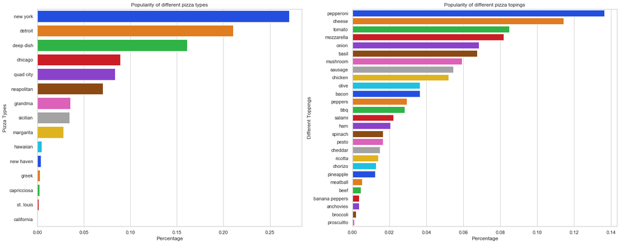

```python
sns.set(style="whitegrid", color_codes=True)

fig, ax = plt.subplots(1,2, sharey = False, figsize=(20,8))

b1 = sns.barplot(y="Pizza_Type", x="Percentage", data=df_types, palette="bright", ax=ax[0]);
b1.set_title("Popularity of different pizza types");
b1.set(ylabel='Pizza Types', xlabel='Percentage');

b1 = sns.barplot(y="Pizza_Topings", x="Percentage", data=df_topings, palette="bright", ax=ax[1]);
b1.set_title("Popularity of different pizza topings");
b1.set(ylabel='Different Toppings', xlabel='Percentage');

plt.tight_layout()
```

Look's like `NY style` is the most popular style, but `Destroit style` is a close second. `Pepperoni` is the most popular topping, more popular than even `cheese`, but since the percentage for `New Haven style` is so small, I think it's safe to say it has more to do with the original poster assume that `cheese`, as a topping, was a given. Out of mozzarella, cheddar, and ricotta, the former is the clear winner. If you were looking for a crowd pleaser, accourding to r/Pizza, if you make a NY style pepperoni pizza, you can't go wrong.

Let's look at the scores the posts get, however. Maybe while `NY style` is mentioned the most, `Chicago` style has the highest score. Let's see what happens when we make a whisker plot. I'm going to use dictionaries to store this data. First we will collect the upvotes of every submission where the title references a specific pizza type or topping.

```python
#key:value for pizza types
d_types = {}
for i in range(len(types)):
    d_types["{0}_upvotes".format(types[i])]=list((pizza_data[pizza_data['Title'].astype(str).str.contains(types[i])])['Upvotes'])

#key:value for pizza toppings
d_topings = {}
for i in range(len(topings)):
    d_topings["{0}_upvotes".format(topings[i])]=list((pizza_data[pizza_data['Title'].astype(str).str.contains(topings[i])])['Upvotes'])
```

Split out the keys and the values for convenience:

```python
labels_type, data_type = d_types.keys(), d_types.values()
labels_top, data_top = d_topings.keys(), d_topings.values()
```

Go ahead and add the values of the duplicate terms together:

```python
#remove duplicates from the dictionary for pizza types
d_types['ny_upvotes']  = list(data_type)[0]+list(data_type)[1]+list(data_type)[2]
d_types['deep dish_upvotes']  = list(data_type)[3]+list(data_type)[4]
d_types['st. louis_upvotes']  = list(data_type)[12]+list(data_type)[13]
d_types['margherita_upvotes']  = list(data_type)[len(types)-2]+list(data_type)[len(types)-1]

del d_types['york_upvotes']
del d_types['new york_upvotes']
del d_types['deep-dish_upvotes']
del d_types['st louis_upvotes']
del d_types['margarita_upvotes']
```

...and then get rid of the unnecessary duplicate keys.

```python
#remove duplicates from the dictionary for pizza toppings
d_topings['basil_upvotes']  = list(data_top)[6]+list(data_top)[7]
d_topings['anchovies_upvotes']  = list(data_top)[20]+list(data_top)[21]
d_topings['tomato_upvotes']  = list(data_top)[22]+list(data_top)[23]
d_topings['bbq_upvotes']  = list(data_top)[24]+list(data_top)[25]+list(data_top)[26]

del d_topings['fresh basil_upvotes']
del d_topings['anchovy_upvotes']
del d_topings['tomatoes_upvotes']
del d_topings['barbeque_upvotes']
del d_topings['barbecue_upvotes']
```

For purposes of printing out some simple statistics, we need at least two values for every key, so we add in zeroes where necessary.

```python
#check if theer are any empty list values and add two zeroes
for i in range(len(list(labels_type))):
    if d_types[list(labels_type)[i]] == []:
        d_types[list(labels_type)[i]].append(0)
        d_types[list(labels_type)[i]].append(0)
    if len(d_types[list(labels_type)[i]]) == 1:
        d_types[list(labels_type)[i]].append(0)

for i in range(len(list(labels_top))):
    if d_topings[list(labels_top)[i]] == []:
        d_topings[list(labels_top)[i]].append(0)
        d_topings[list(labels_top)[i]].append(0)
    if len(d_topings[list(labels_top)[i]]) == 1:
        d_topings[list(labels_top)[i]].append(0)
```

Print out some simple descriptive statistics for pizza types:

```python
for st,vals in d_types.items():
    print("For {}:\t\tavg : {}\tmax : {}\tstdev : {}\tvar : {}\n".format(st,round(mean(vals),2),max(vals),round(stdev(vals),2),round(variance(vals),2) ))
```

```
For ny_upvotes:		avg : 63.21	max : 1978	stdev : 212.54	var : 45174.43

For deep dish_upvotes:		avg : 54.99	max : 1071	stdev : 144.38	var : 20846.54

For detroit_upvotes:		avg : 29.24	max : 304	stdev : 71.29	var : 5082.44

For chicago_upvotes:		avg : 26.75	max : 91	stdev : 43.09	var : 1856.92

For grandma_upvotes:		avg : 28.3	max : 139	stdev : 34.26	var : 1173.49

For neapolitan_upvotes:		avg : 31	max : 110	stdev : 30.19	var : 911.73

For sicilian_upvotes:		avg : 81	max : 367	stdev : 160.04	var : 25612.5

For hawaiian_upvotes:		avg : 0	max : 0	stdev : 0.0	var : 0

For greek_upvotes:		avg : 0	max : 0	stdev : 0.0	var : 0

For st. louis_upvotes:		avg : 0	max : 0	stdev : 0.0	var : 0

For california_upvotes:		avg : 0	max : 0	stdev : 0.0	var : 0

For new haven_upvotes:		avg : 2	max : 4	stdev : 2.83	var : 8

For capricciosa_upvotes:		avg : 3	max : 6	stdev : 4.24	var : 18

For quad city_upvotes:		avg : 0	max : 0	stdev : 0.0	var : 0

For margherita_upvotes:		avg : 44.38	max : 596	stdev : 97.67	var : 9538.77
```

Print out some simple descriptive statistics for pizza topings:

```python
for st,vals in d_topings.items():
    print("For {}:\t\tavg : {}\tmax : {}\tstdev : {}\tvar : {}\n".format(st,round(mean(vals),2),max(vals),round(stdev(vals),2),round(variance(vals),2) ))
```

```
For pepperoni_upvotes:		avg : 56.58	max : 722	stdev : 128.79	var : 16586.19

For olive_upvotes:		avg : 14.87	max : 72	stdev : 16.47	var : 271.26

For cheese_upvotes:		avg : 31.05	max : 939	stdev : 80.95	var : 6552.8

For cheddar_upvotes:		avg : 53.23	max : 428	stdev : 101.55	var : 10312.42

For ricotta_upvotes:		avg : 39.35	max : 428	stdev : 95.92	var : 9199.71

For mozzarella_upvotes:		avg : 44.86	max : 1240	stdev : 140.46	var : 19730.32

For basil_upvotes:		avg : 28.11	max : 363	stdev : 49.46	var : 2446.13

For pineapple_upvotes:		avg : 19.15	max : 135	stdev : 34.81	var : 1211.4

For spinach_upvotes:		avg : 17.5	max : 76	stdev : 20.16	var : 406.58

For onion_upvotes:		avg : 29.27	max : 429	stdev : 67.37	var : 4538.43

For mushroom_upvotes:		avg : 30.06	max : 529	stdev : 68.61	var : 4707.43

For bacon_upvotes:		avg : 20.38	max : 219	stdev : 36.91	var : 1362.17

For sausage_upvotes:		avg : 59.47	max : 745	stdev : 119.2	var : 14209.27

For salami_upvotes:		avg : 29.69	max : 304	stdev : 55.28	var : 3055.38

For proscuitto_upvotes:		avg : 43	max : 86	stdev : 60.81	var : 3698

For chicken_upvotes:		avg : 26.48	max : 854	stdev : 102.99	var : 10606.61

For ham_upvotes:		avg : 33.57	max : 427	stdev : 77.53	var : 6011.36

For peppers_upvotes:		avg : 23.06	max : 300	stdev : 43.91	var : 1928.02

For banana peppers_upvotes:		avg : 11.4	max : 20	stdev : 6.99	var : 48.8

For anchovies_upvotes:		avg : 4.4	max : 10	stdev : 3.71	var : 13.8

For tomato_upvotes:		avg : 40.12	max : 514	stdev : 82.81	var : 6857.75

For bbq_upvotes:		avg : 53.89	max : 529	stdev : 137.11	var : 18800.46

For broccoli_upvotes:		avg : 13	max : 26	stdev : 18.38	var : 338

For beef_upvotes:		avg : 23.29	max : 75	stdev : 26.38	var : 695.9

For meatball_upvotes:		avg : 94.86	max : 529	stdev : 192.55	var : 37075.81

For pesto_upvotes:		avg : 14.19	max : 42	stdev : 12.16	var : 147.86

For chorizo_upvotes:		avg : 52	max : 427	stdev : 110.78	var : 12271.54
```

Let's go ahead and look at some box plots for easier visualization.

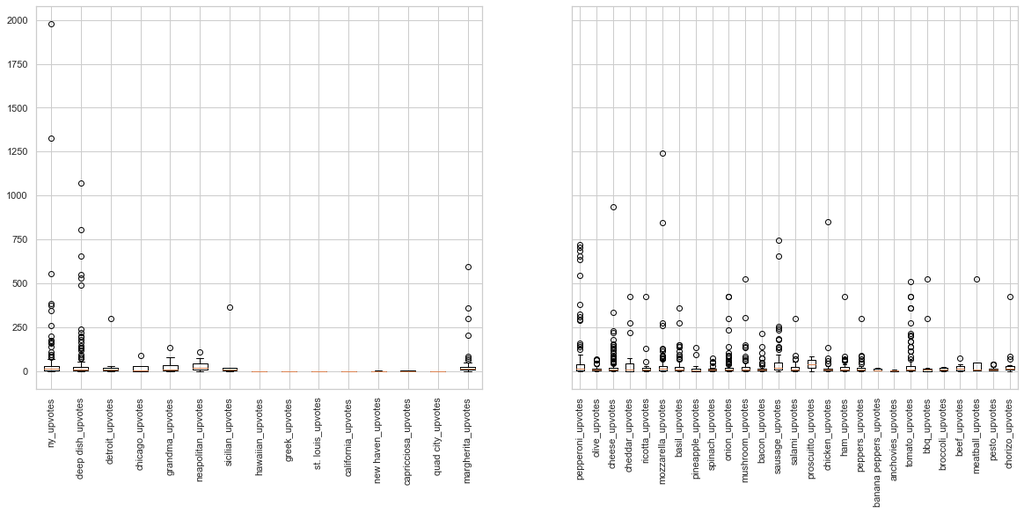

```python
fig, ax = plt.subplots(1,2, sharey = True, figsize=(20,8))
ax[0].boxplot(data_type);
ax[0].set_xticklabels(labels_type, rotation=90);

ax[1].boxplot(data_top);
ax[1].set_xticklabels(labels_top, rotation=90);
```

# 6.) Time series analysis

Now I want to see if COVID had an impact on frequency of submissions with `first` in the title. I'm curious to see if the scores on submissions has been going up, but I'm most curious to see if there was a spike in submissions in March, and if that was a sustained spike or if it fell off.

But I have all these other metrics, so I want to see if comments, upvotes, awards, and gilded has increased over time.

```python
#need to get the sum of columns for each unique day
pd_sum = pizza_data.groupby( ["Date"] ).sum()
#drop columns that don't make sense to sum up
pd_sum = pd_sum.drop(columns=['Year', 'Month','Day','Upvote_Ratio'])
#convert to dataframe
pd_sum = pd.DataFrame({'Total_Upvotes' : (pizza_data.groupby( ["Date"] ).sum())['Upvotes'],
              'Total_Comments' : (pizza_data.groupby( ["Date"] ).sum())['Total_Comments'],
              'Total_Awards' : (pizza_data.groupby( ["Date"] ).sum())['Total_Awards'],
              'Total_Gilded' : (pizza_data.groupby( ["Date"] ).sum())['Gilded'],
             }).reset_index()
#convert date column to datetime type
pd_sum['Date'] = pd.to_datetime(pd_sum['Date'])
```

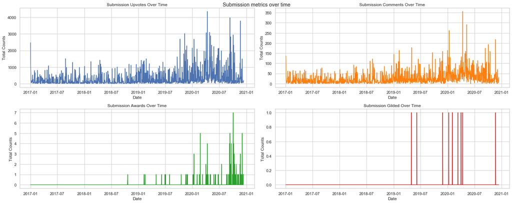

```python
fig, axs = plt.subplots(2,2, figsize=(20,8))

fig.suptitle('Submission metrics over time')
axs[0,0].plot(pd_sum['Date'], pd_sum['Total_Upvotes'])
axs[0, 0].set_title('Submission Upvotes Over Time')
axs[0,1].plot(pd_sum['Date'], pd_sum['Total_Comments'], 'tab:orange')
axs[0, 1].set_title('Submission Comments Over Time')
axs[1,0].plot(pd_sum['Date'], pd_sum['Total_Awards'], 'tab:green')
axs[1, 0].set_title('Submission Awards Over Time')
axs[1,1].plot(pd_sum['Date'], pd_sum['Total_Gilded'], 'tab:red')
axs[1, 1].set_title('Submission Gilded Over Time')

for ax in axs.flat:
    ax.set(xlabel='Date', ylabel='Total Counts')

plt.tight_layout()
```

So we are already seeing something here that might imply to us that there was a lot of activity early in 2020... it looks like every year there is a spike in activity in January - the New Year. Awards and gilded looks to be less than useful metrics, implemented recently.

Let's finally go ahead and take a look at the frequency of submissions with `first` in the title.

```python
#grouping data by date to get frequency
gb_date = pd.DataFrame({'Count' : pizza_data.groupby( ["Date"] ).size()}).reset_index()
gb_date['Date']= pd.to_datetime(gb_date['Date'])
```

I want a very granular look first, so I'll be plotting using the day as well.

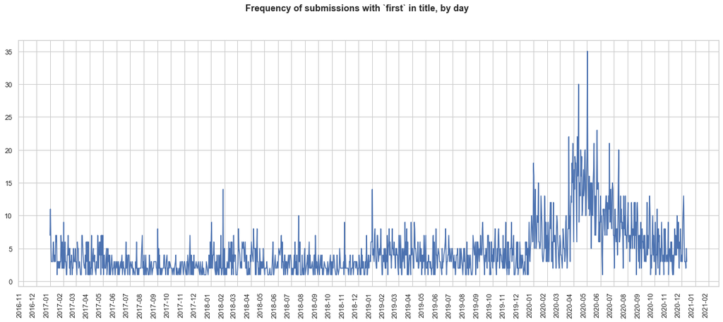

```python
fig, ax = plt.subplots(figsize=(20,8))
ax.plot(gb_date['Date'],gb_date['Count'])

ax.xaxis.set_major_locator(mdates.MonthLocator())
ax.grid(True)
fig.autofmt_xdate(rotation=90)
fig.suptitle("Frequency of submissions with `first` in title, by day", fontweight ="bold")

plt.show()
```

I want something smoother and a little easier to visually digest, so I'll be plotting only up to the month.

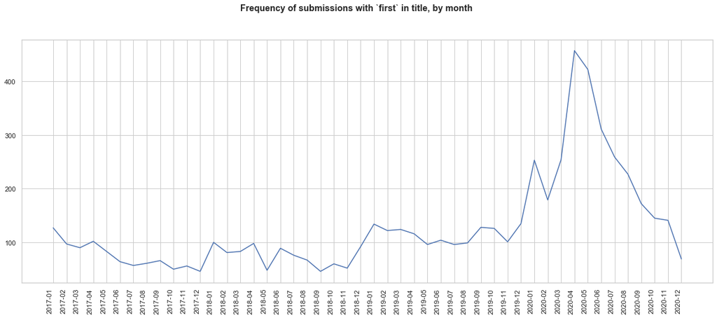

```python
gb_ym = pizza_data.groupby(['Year_Month']).Date.count()

fig = plt.figure(figsize=(20,8))
ax2 = fig.add_subplot(111)

ax2.plot(gb_ym)
ax2.grid(True)
fig.autofmt_xdate(rotation=90)
fig.suptitle("Frequency of submissions with `first` in title, by month", fontweight ="bold")
plt.show()
```

Very clearly in both we see that there are peaks for the New Year but in 2020, while the posts dipped in February, they went back up again for March. The peak is actually April, which would coincide with Spring Break fro university students. Then we can see that the values trailed off, and by December we are back to about regular number of postings with `first` in the title. If we had January 2021 data no doubt we woudl see a peak there consistent with previous years, but no peak like was seen in April. The stay-at-home orders appear to have allowed a lot of people to try some pizza firsts!

# 7.) Conclusion

In general, posts with `first` in the title do not get a lot of comment interaction or have high scores. However, there are some outliers with some extremely high scores and total comments. In general the upvote ratio is very high meaning that even though posts don't get a whole heck of a lot of interaction, they're not being downvoted, except in extreme outlier cases.

`Deep dish`, `detroit style`, `crust`, `pepperoni` are common words in posts, but the top 100 posts (by upvote) have `new`, `oven`, `quarantine`, `ooni`. The top 100 posts might be indicated that, due to quarantine, a significant amount of people have obtained new ooni koda pizza ovens, and are trying them out successfully.

The most common state to be mentioned is NY, even when subtracting mentions of `NY Style` from this mention count. The next most commonly mentioned states are Illinois, New Jersey, Connecticut, California, and Pennsylvania.

Looking at the change over time in total awards and gilded was not very useful besides really showing when both systems were implemented on Reddit. Checking comments and upvotes, we see over time that there is an increase in January every month, though the month of January in 2020 had the highest uptick out of any year. We noticed that upvotes and comments spiked dramatically towards the beginning of Spring. When we check the frequency of posts with the word `first` in their title, both on a highly granular day scale, and then on a monthly scale, we see that there was a dramatic uptick during March which peaked in April, before steadily decreasing. Mentions of `first` in submissions seems to have returned to a baseline level. So the stay-at-home orders appear to have impacted individuals by allowing them more time to try out making pizza for the first time, and it might have influenced people's decision to buy a new pizza oven to use. Also, first time pizza makers on the whole seem to go for a classic: a NY style topped with pepperoni.